# ManuallyTuneandPredict2classedMLWAM

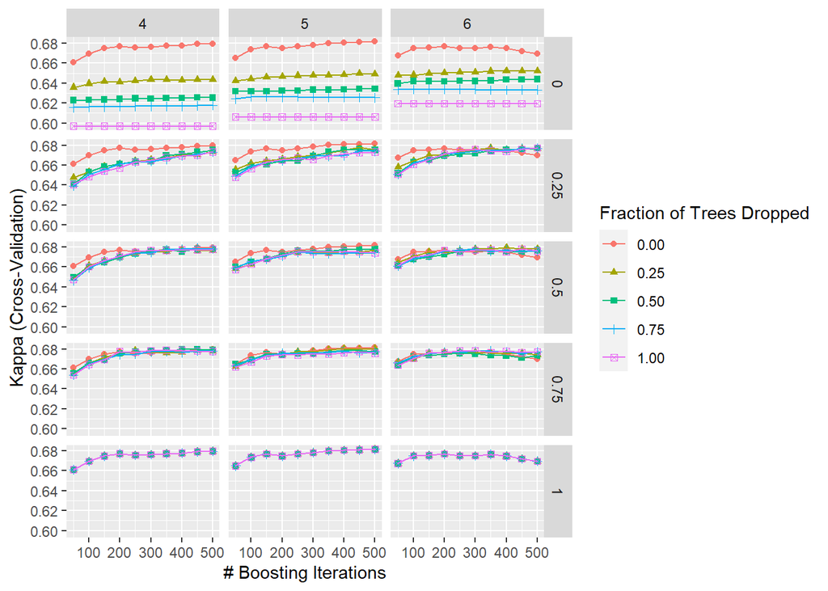

```r
ggplot(xgbDARTtuningmodel2classedseed2)
```

Tune Column and Row Sampling. Subsampling occurs once for every tree constructed.

```r
XGBoostgrid3 <- expand.grid(
  nrounds = seq(from = 50, to = 500, by = 50),
  eta = xgbDARTtuningmodel2classedseed$bestTune$eta,
  max_depth = xgbDARTtuningmodel2classedseed2$bestTune$max_depth,
  gamma = 0,
  colsample_bytree = c(0.5, 0.75, 1.0),
  min_child_weight = c(1),
  rate_drop = xgbDARTtuningmodel2classedseed2$bestTune$rate_drop,
  skip_drop = xgbDARTtuningmodel2classedseed2$bestTune$skip_drop,
  subsample = c(0.5, 0.75, 1.0)
)

xgbDARTtuningmodel2classedseed3 <- caret::train(binaryMoisture~., data = binarytrainingData, trControl = tune_control, tuneGrid = XGBoostgrid3, method = "xgbDART",verbose = TRUE, metric="Kappa")

xgbDARTtuningmodel2classedseed3$bestTune
```

```
##    nrounds max_depth  eta gamma subsample colsample_bytree rate_drop skip_drop
## 40     500         5 0.05     0      0.75              0.5         0         0
##    min_child_weight
## 40                1
```

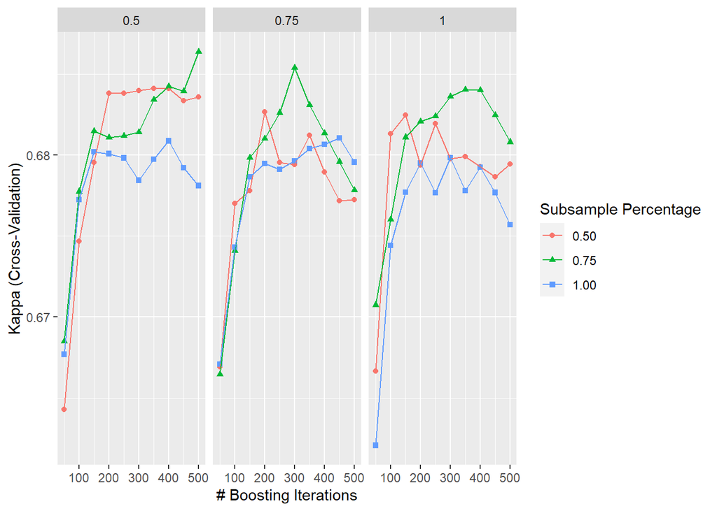

```r
ggplot(xgbDARTtuningmodel2classedseed3)
```

min_child_weigth Controls the minimum number of observations (instances) in a terminal node. The minimum value for this parameter is 1, which allows the tree to have terminal nodes with only one observation. If we use bigger values we limit a possible perfect fit on some observations.

```r
set.seed(42)

XGBoostgrid4 <- expand.grid(
  nrounds = seq(from = 50, to = 500, by = 50),
  eta = xgbDARTtuningmodel2classedseed$bestTune$eta,
  max_depth = xgbDARTtuningmodel2classedseed2$bestTune$max_depth,
  gamma = 0,
  colsample_bytree = xgbDARTtuningmodel2classedseed3$bestTune$colsample_bytree,
  min_child_weight = c(1, 2, 3),
  rate_drop = xgbDARTtuningmodel2classedseed2$bestTune$rate_drop,
  skip_drop = xgbDARTtuningmodel2classedseed2$bestTune$skip_drop,
  subsample = xgbDARTtuningmodel2classedseed3$bestTune$subsample)

xgbDARTtuningmodel2classedseed4 <- caret::train(binaryMoisture~., data = binarytrainingData, trControl = tune_control, tuneGrid = XGBoostgrid4, method = "xgbDART",verbose = TRUE, metric="Kappa")
xgbDARTtuningmodel2classedseed4$bestTune
```

```
##    nrounds max_depth  eta gamma subsample colsample_bytree rate_drop skip_drop
## 10     500         5 0.05     0      0.75              0.5         0         0
##    min_child_weight
## 10                1
```

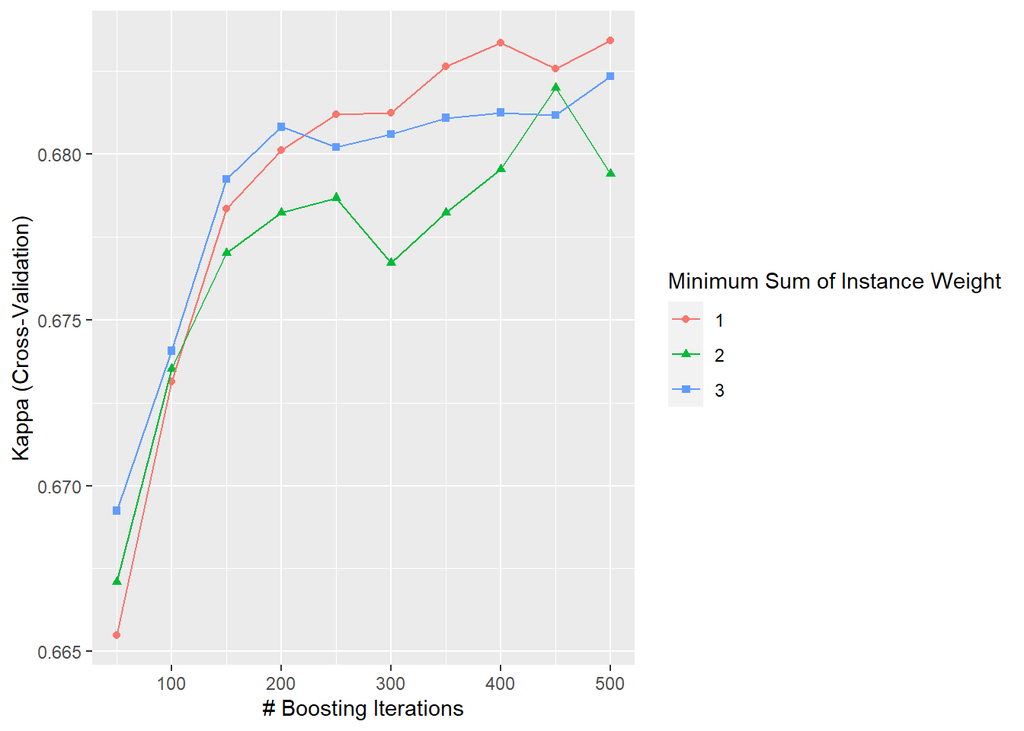

```r
ggplot(xgbDARTtuningmodel2classedseed4)
```

Gamma controls regularization (prevents overfitting). Gamma is minimum loss reduction required to make a further partition on a leaf node of the tree. The larger gamma is, the more conservative the algorithm will be.The main consequence of using a gamma different from 0 is to stop the algorithm from growing useless trees that barely reduce the in-sample error and are likely to result in over-fitting

```r
set.seed(42)

XGBoostgrid5 <- expand.grid(
  nrounds = seq(from = 50, to = 500, by = 50),
  eta = xgbDARTtuningmodel2classedseed$bestTune$eta,
  max_depth = xgbDARTtuningmodel2classedseed2$bestTune$max_depth,
  gamma = c(0, 0.1, 0.25, 0.5, 0.75, 1.0),
  colsample_bytree = xgbDARTtuningmodel2classedseed3$bestTune$colsample_bytree,
  min_child_weight = xgbDARTtuningmodel2classedseed4$bestTune$min_child_weight,
  rate_drop = xgbDARTtuningmodel2classedseed2$bestTune$rate_drop,
  skip_drop = xgbDARTtuningmodel2classedseed2$bestTune$skip_drop,
  subsample = xgbDARTtuningmodel2classedseed3$bestTune$subsample)

xgbDARTtuningmodel2classedseed5 <- caret::train(binaryMoisture~., data = binarytrainingData, trControl = tune_control, tuneGrid = XGBoostgrid5, method = "xgbDART",verbose = TRUE, metric="Kappa")
xgbDARTtuningmodel2classedseed5$bestTune
```

```
##   nrounds max_depth  eta gamma subsample colsample_bytree rate_drop skip_drop
## 8     400         5 0.05     0      0.75              0.5         0         0
##   min_child_weight
## 8                1
```

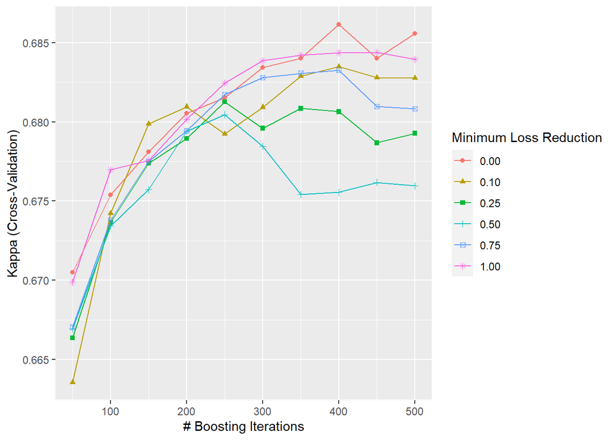

```r
ggplot(xgbDARTtuningmodel2classedseed5)
```

Now we will fix all hyperparamters and train that model on all trainingdata and then test it on the test data.

```r
Final_control <- caret::trainControl(method = "none", verboseIter = FALSE)

XGBoostgrid6 <- expand.grid(
  nrounds = xgbDARTtuningmodel2classedseed5$bestTune$nrounds,
  eta = xgbDARTtuningmodel2classedseed5$bestTune$eta,
  max_depth = xgbDARTtuningmodel2classedseed5$bestTune$max_depth,
  gamma = xgbDARTtuningmodel2classedseed5$bestTune$gamma,
  colsample_bytree = xgbDARTtuningmodel2classedseed5$bestTune$colsample_bytree,
  min_child_weight = xgbDARTtuningmodel2classedseed5$bestTune$min_child_weight,
  rate_drop = xgbDARTtuningmodel2classedseed5$bestTune$rate_drop,
  skip_drop = xgbDARTtuningmodel2classedseed5$bestTune$skip_drop,
  subsample = xgbDARTtuningmodel2classedseed3$bestTune$subsample)

xgbDARTtuningmodel2classedseed6 <- caret::train(binaryMoisture~., data = binarytrainingData, trControl = Final_control, tuneGrid = XGBoostgrid6, method = "xgbDART",verbose = TRUE, metric="Kappa")
xgbDARTtuningmodel2classedseed6$bestTune
```

```
##   nrounds  eta max_depth gamma colsample_bytree min_child_weight rate_drop
## 1     400 0.05         5     0              0.5                1         0
##   skip_drop subsample
## 1         0      0.75
```

Test model on the hold out testing data. Class 2 = Wet Class 1 = Dry

```r
XGBOOSTPredictions <-predict(xgbDARTtuningmodel2classedseed6, binarytestData,ntree_limit=nrounds)
cmXGBOOST1 <-confusionMatrix(XGBOOSTPredictions, reference=binarytestData$binaryMoisture, positive="1")
print(cmXGBOOST1)
```

```
## Confusion Matrix and Statistics
##
##           Reference
## Prediction    1    2
##          1 2134  316
##          2  269 1209
##
##                Accuracy : 0.8511
##                  95% CI : (0.8395, 0.8621)
##     No Information Rate : 0.6118
##     P-Value [Acc > NIR] : < 2e-16
##
##                   Kappa : 0.6847
##
##  Mcnemar's Test P-Value : 0.05719
##
##             Sensitivity : 0.8881
##             Specificity : 0.7928
##          Pos Pred Value : 0.8710
##          Neg Pred Value : 0.8180
##              Prevalence : 0.6118
##          Detection Rate : 0.5433
##    Detection Prevalence : 0.6237
##       Balanced Accuracy : 0.8404
##
##        'Positive' Class : 1
##
```

```r
XGBoosttable1<-cmXGBOOST1$byClass
XGBoosttable1
```

```
##          Sensitivity          Specificity       Pos Pred Value
##            0.8880566            0.7927869            0.8710204
##       Neg Pred Value            Precision               Recall
##            0.8179973            0.8710204            0.8880566
##                   F1           Prevalence       Detection Rate
##            0.8794560            0.6117617            0.5432790
## Detection Prevalence    Balanced Accuracy
##            0.6237271            0.8404217
```

```r
cmXGBOOST0<-confusionMatrix(XGBOOSTPredictions, reference = binarytestData$binaryMoisture,positive="2")
print(cmXGBOOST0)
```

```
## Confusion Matrix and Statistics
##
##           Reference
## Prediction    1    2
##          1 2134  316
##          2  269 1209
##
##                Accuracy : 0.8511
##                  95% CI : (0.8395, 0.8621)
##     No Information Rate : 0.6118
##     P-Value [Acc > NIR] : < 2e-16
##
##                   Kappa : 0.6847
##
##  Mcnemar's Test P-Value : 0.05719
##
##             Sensitivity : 0.7928
##             Specificity : 0.8881
##          Pos Pred Value : 0.8180
##          Neg Pred Value : 0.8710
##              Prevalence : 0.3882
##          Detection Rate : 0.3078
##    Detection Prevalence : 0.3763
##       Balanced Accuracy : 0.8404
##
##        'Positive' Class : 2
##
```

```r
XGBoosttable0<-cmXGBOOST0$byClass
XGBoosttable0
```

```
##          Sensitivity          Specificity       Pos Pred Value
##            0.7927869            0.8880566            0.8179973
##       Neg Pred Value            Precision               Recall
##            0.8710204            0.8179973            0.7927869
##                   F1           Prevalence       Detection Rate
##            0.8051948            0.3882383            0.3077902
## Detection Prevalence    Balanced Accuracy
##            0.3762729            0.8404217
```

```r
ImportantVariables<-varImp(xgbDARTtuningmodel2classedseed6, scale = FALSE)
importanceplot<-ggplot(ImportantVariables, top = 23) +theme_bw() + theme(panel.border = element_blank(), panel.grid.major = element_blank(), panel.grid.minor = element_blank(), axis.line = element_line(colour = "black"))
ggsave(importanceplot, file = "X:/XGBoostArticle/importanceplot2classes.png", dpi = 600)
```

When we put the model into production we will use all data to train the model without resampling. Both the training data and the testing data.

```r
set.seed(42)

Final_control <- caret::trainControl(method = "none", verboseIter = FALSE)
Final_grid <- expand.grid(
  nrounds = xgbDARTtuningmodel2classedseed6$bestTune$nrounds,
  eta = xgbDARTtuningmodel2classedseed6$bestTune$eta,
  max_depth = xgbDARTtuningmodel2classedseed6$bestTune$max_depth,
  gamma = xgbDARTtuningmodel2classedseed6$bestTune$gamma,
  colsample_bytree = xgbDARTtuningmodel2classedseed6$bestTune$colsample_bytree,
  min_child_weight = xgbDARTtuningmodel2classedseed6$bestTune$min_child_weight,
  rate_drop = xgbDARTtuningmodel2classedseed6$bestTune$rate_drop,
  skip_drop = xgbDARTtuningmodel2classedseed6$bestTune$skip_drop,
  subsample = xgbDARTtuningmodel2classedseed6$bestTune$subsample
)

xgbDARTtuningmodel_PredictModel <- caret::train(binaryMoisture~., data = binarydataset, trControl = Final_control, tuneGrid = Final_grid, method = "xgbDART",verbose = TRUE, metric="Kappa")
```

Save the trained model for later use

```r
saveRDS(xgbDARTtuningmodel_PredictModel, "X:/MLWAM_Production/SavedModel/MLWAM2ClassesProbability.rds")
```